# Computer Practical - Survival Analysis

SB, LvdB

2025-10-02

# Instructions

Fill in parts labeled as **fillin** with your own R-code and your interpretation of code/results. After finishing, created an html version of your CP using `knitr` and submit it to brightspace.

- Fill in your names
- Complete the CP. During the alotted time frame, you can get assistance while working on the questions. Solutions become available during the practical which should only be used when becoming stuck. First try to solve the questions yourself.
- Upload your CP to brightspace. **Students working together each have to submit the identical report under their own name**. Include the R-markdown and a rendered version (pdf or html).
- Deadline for submission is the day before the Exam

You can freely use other than the suggested functions if you are already familiar with other functions/frameworks (such as the tidyverse). You can also use your own functions which then have to be included into the R-markdown/submission.

# Authors

# Learning Objectives

Learning Objectives (understand/be able to)

- Manually compute a Kaplan-Meier curve
- Calculate the ICC using a mixed model
- Create and interpret an Bland-Altman plot
- Interpret results from reliability analyses

# Part 1: Kaplan-Meier curve calculation

The survival times (in hours) of the mice were

```
  50  50*  51  66*  82  92  120*  140 150 180 190
```

A ‘*’ indicates that an observation was censored (i.e. ’50*’ means that the actual survival time of the mouse is not observed, but the mouse was still alive 50 hours after receiving the drug).

## Q1.1: Calculate the Kaplan-Meier curve by hand

Complete the following table. When both an event and censoring happens at a point in time (50), assume that leaving the risk set happens after you calculate the hazard.

[output not shown]

Check your computations with R. Use the following code.

```r
  library('survival')
  data <- readRDS('data/mice.rds')
  data$Event <- data$Death == 'death'
  km <- survfit(Surv(Time, Event) ~ 1, data)
  summary(km)
```

```
## Call: survfit(formula = Surv(Time, Event) ~ 1, data = data)
##
##  time n.risk n.event survival std.err lower 95% CI upper 95% CI
##    50     11       1    0.909  0.0867       0.7541        1.000
##    51      9       1    0.808  0.1225       0.6004        1.000
##    82      7       1    0.693  0.1498       0.4533        1.000
##    92      6       1    0.577  0.1634       0.3314        1.000
##   140      4       1    0.433  0.1750       0.1960        0.956
##   150      3       1    0.289  0.1658       0.0936        0.890
##   180      2       1    0.144  0.1315       0.0242        0.861
##   190      1       1    0.000     NaN           NA           NA
```

The term `Surv(Time, Event)` defines a survival time object in R that combines a column measuring time with a second column indicating censoring/event (so called event indicator). The indicator should be 0 for censoring and 1 when an event happened (check this with `as.integer(data$Event)`).

## Q1.2: What is the median survival?

Plot the Kaplan-Meier curve.

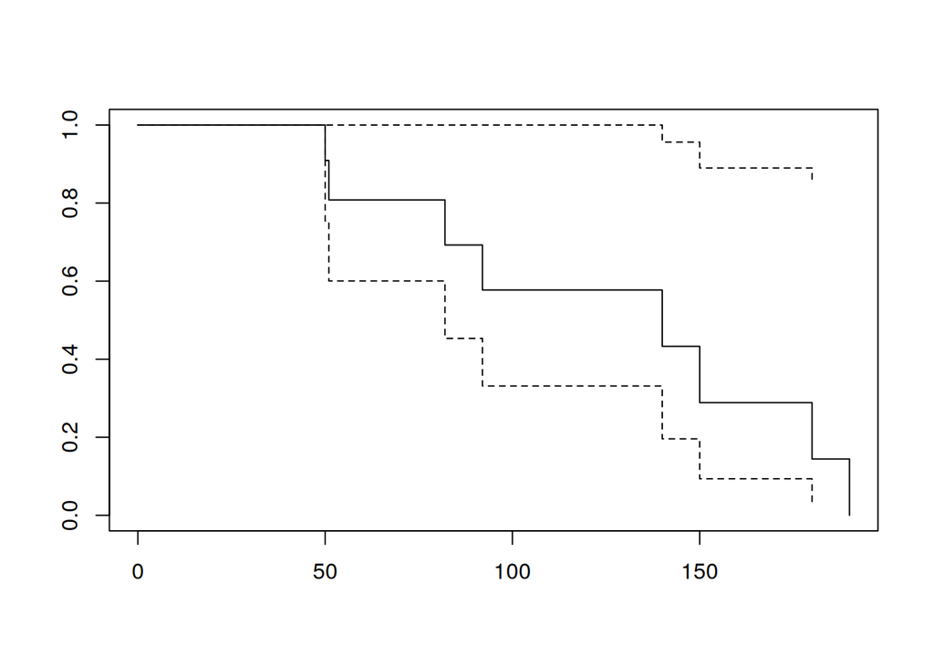

```r
  plot(km)
```

Read off median suvival.

# Part 2: Comparing groups

In a clinical trial on elderly patients who visited their general physician with complains on shortness of breath were included. The patients were randomized in two groups, one group received Respisonide two times a day for a period of 2 months, the other group received a placebo.

```r
  myPath <- 'data/breath.rds'   # <-- change to match your file location
  data <- readRDS(myPath)
```

## Q2.1: Descriptive analysis

Calculate how many patients were in the Respisonide group and how many patients in the control group. Variable `group` contains information on treatment arm. Interpret your finding.

## Q2.2: Create Kaplan-Meier curves for the two treatment arms.

The formula provided to `survfit` can take variable on the right-hand side that defines groups in the analysis. For this, use variable `group`. Time of follow-up is given in variable `efi` end censoring is contained in variable `estat`. Produce a new variable, which is `TRUE/FALSE` coded and can be used as event indicator.

```r
  data$event <- data$estat == 'event'
```

Produce Kaplan-Meier curves for the groups.

After 500 days, is the hazard ratio of the Respisonide group larger, roughly equal to, or smaller than 1, compared to the placebo group?

## Q2.3 Log-rank test

Calculate a log-rank test using the `survdiff` function. It takes the same arguments as `surffit`. Do the groups differ significantly?

## Q2.4 Report survival in the groups.

Report survival after two years (`365*2` days) in the two groups, together with 95% confidence intervals. Use `summary(km)` to get this information (you can read off the values from that output).

## Q2.4 Number needed to treat

Calculate the number needed to treat to prevent one event in the first two years.

## Q2.4 Harzard ratio

Calculate the hazard ratio of treatment vs placebo group for event-free survival using a Cox regression. Use R-function `coxph` for the computation. The function takes the same arguments as `survfit`.

## Q2.5 FEV

A secondary outcome measure of the study is the FEV at one month (variable `FEV_4`) after the start of the study. Which statistical tests can be used to compare the mean FEV values after one month (you may assume that the FEV is approximately normal distributed)?

Apply your proposed analysis.

Create a histogram for the baseline measurement of FEV (variable `FEV_0`).

Should this variable be included in the analysis of `FEV_4`? Why or why not? Is `FEV_0` a confounder?

Conduct a new analysis and interpret, if necessary.

Re-analyze the cox-model by including `FEV_0`. Interpret your findings.

## Q2.6 Side effects

Occurence of side effects was recorded in variable `sideeffi`. The time at which a side effects occurred was recorded in variable `sidetime`. If no side effect occured, this variable records the time of follow-up.

Conduct an analysis which compares occurrence of side effects between the treatment groups. Choose and conduct an analysis.

Interpret your findings.

## Q2.6 Overall conclusions

From your analyses, what is your conclusion about treatment with Respisonide. Make a recommendation based on efficacy and safety.